# JW_Use-and-modify

James Waterford

2023-04-04

The `apply` function allows us to apply a function to a vector or list of values iteratively. This helps minimize errors in code and makes the analyses more efficient.

`sapply()` simplifies an output to a vector.

`lapply()` returns an output in the form of a list.

`mapply()` applies FUN to the first elements of each … argument.

We will show them in action soon. But first, let’s prepare a full data set to work with.

## Calculating the mass of a bunch of dinosaurs.

Earlier, we practiced creating functions that take a single variable and modify it.

Now we are going to add onto this, by manipulating entire vectors through a function.

First we will create a basic function that returns the theoretical mass, based on the given length of limb from the dinosaur, *Theropoda*.

```r
mass_from_length_theropoda <- function(length){
  mass <- 0.73*length^3.63
  return(mass)
}
```

# Theropda lengths

Now that we’ve created a function, let’s test it with a list of values.

First, we will generate a vector of lengths before we run it through our function.

```r
theropoda_lengths <- c(17.8013631070471, 20.3764452071665, 14.0743486294308, 25.65782386974, 26.0952008049675, 20.3111541103134, 17.5663244372533, 11.2563431277577, 20.081903202614, 18.6071626441984, 18.0991894513166, 23.0659685685892, 20.5798853467837, 25.6179254233558, 24.3714331573996, 26.2847248252537, 25.4753783544473, 20.4642089867304, 16.0738256364701, 20.3494171706583, 19.854399305869, 17.7889814608919, 14.8016421998303, 19.6840911485379, 19.4685885050906, 24.4807784966691, 13.3359960054899, 21.5065994598917, 18.4640304608411, 19.5861532398676, 27.084751999756, 18.9609366301798, 22.4829168046521, 11.7325716149514, 18.3758846100456, 15.537504851634, 13.4848751773738, 7.68561192214935, 25.5963348603783, 16.588285389794)

mass_from_length_theropoda(theropoda_lengths)
```

```
##  [1]  25262.027  41253.332  10767.568  95233.732 101260.017  40775.516
##  [7]  24072.130   4785.145  39129.521  29666.193  26830.297  64700.869
## [13]  42768.180  94697.262  79013.471 103955.226  92798.465  41901.983
## [19]  17439.569  41055.045  37544.201  25198.303  12928.490  36388.290
## [25]  34962.862  80307.929   8854.525  50183.194  28846.165  35735.369
## [31] 115908.187  31765.368  58958.713   5561.862  28349.410  15418.314
## [37]   9218.648   1197.666  94407.873  19552.500
```

While this is functional, it is is very limited. We are relying on two coefficients–let’s call them `a` and `b` to be constant through all samples.

More likely, `a` and `b` are two coefficients that need to change. So let’s add them as variables now.

```r
mass_from_length <- function(length, a, b){
  ## We use the `<<-` assignment operator to make a global variable ##
  mass <- a * length^b
  dino_data <<- data.frame(length)
  ## Then we create a column for mass
  dino_data %>%
    mutate(mass = mass_from_length_theropoda(theropoda_lengths)) ->> dino_data
  return(dino_data)
} ## Here we will concatenate vectors for `a` and `b` ##
a_values <- c(0.759, 0.751, 0.74, 0.746, 0.759, 0.751, 0.749, 0.751, 0.738, 0.768, 0.736, 0.749, 0.746, 0.744, 0.749, 0.751, 0.744, 0.754, 0.774, 0.751, 0.763, 0.749, 0.741, 0.754, 0.746, 0.755, 0.764, 0.758, 0.76, 0.748, 0.745, 0.756, 0.739, 0.733, 0.757, 0.747, 0.741, 0.752, 0.752, 0.748)

b_values <- c(3.627, 3.633, 3.626, 3.633, 3.627, 3.629, 3.632, 3.628, 3.633, 3.627, 3.621, 3.63, 3.631, 3.632, 3.628, 3.626, 3.639, 3.626, 3.635, 3.629, 3.642, 3.632, 3.633, 3.629, 3.62, 3.619, 3.638, 3.627, 3.621, 3.628, 3.628, 3.635, 3.624, 3.621, 3.621, 3.632, 3.627, 3.624, 3.634, 3.621)

mass_from_length(length = theropoda_lengths, a = a_values, b = b_values)
```

```
##       length       mass
## 1  17.801363  25262.027
## 2  20.376445  41253.332
## 3  14.074349  10767.568
## 4  25.657824  95233.732
## 5  26.095201 101260.017
## 6  20.311154  40775.516
## 7  17.566324  24072.130
## 8  11.256343   4785.145
## 9  20.081903  39129.521
## 10 18.607163  29666.193
## 11 18.099189  26830.297
## 12 23.065969  64700.869
## 13 20.579885  42768.180
## 14 25.617925  94697.262
```

[output cut: 26 more lines]

## Lengthy Conditions

If we have values that are outside of the normal range, we can try to remove them with `IF/ELSE` functions.

```r
mass_from_length_max <- function(length) {
  if(length < 20) {
    mass <- 0.73*length^3.63
    } else {
      mass <- NA
    }
  return(mass)
}
mass_from_length_max(length = theropoda_lengths)
```

```
## Error in if (length < 20) {: the condition has length > 1
```

Hmm. So why didn’t that work. Well this program just tested all the values at the exact same time. Because we have *theropoda_lengths* as a `vector`, we need to call a function that will evaluate each value individually.

```r
sapply(theropoda_lengths,mass_from_length_max)
```

```
##  [1] 25262.027        NA 10767.568        NA        NA        NA 24072.130
##  [8]  4785.145        NA 29666.193 26830.297        NA        NA        NA
## [15]        NA        NA        NA        NA 17439.569        NA 37544.201
## [22] 25198.303 12928.490 36388.290 34962.862        NA  8854.525        NA
## [29] 28846.165 35735.369        NA 31765.368        NA  5561.862 28349.410
## [36] 15418.314  9218.648  1197.666        NA 19552.500
```

## A Data Set of Dinosaur Lengths

from https://lunasare.github.io/spring2023-data-science/exercises/Loops-size-estimates-by-name-apply-R/

```r
dino_dat <- read.csv("../197-raw_storage/dinosaur_lengths.csv")
```

```r
get_mass_from_length_by_name <-function(length,name){
  if(name == "Stegosauria"){
    a = 10.95
    b = 2.64
  }
  else if(name == "Theropoda"){
    a = 0.73
    b = 3.63
  }
  else if(name == "Sauropoda"){
    a = 214.44
    b = 1.46
  }
  else{
    a = NA
    b = NA
  }
  mass <- a * length^b

}
```

```r
mapply(get_mass_from_length_by_name, length = dino_dat$lengths, name = dino_dat$species) -> dino_mass

dino_dat %>%
  rowwise() %>%
  mutate(masses = get_mass_from_length_by_name(lengths,species)) -> dino_dat
```

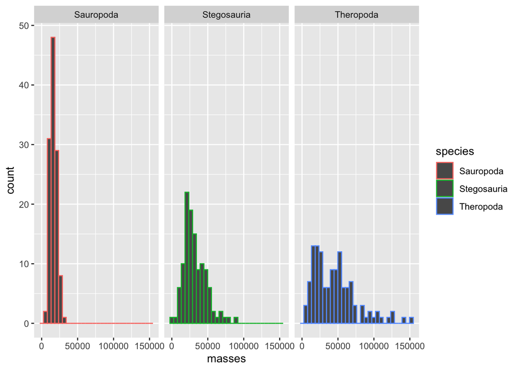

```r
library(ggplot2)
dino_dat %>%
  filter(!is.na(masses)) %>%
  ggplot() +
  geom_histogram(mapping = aes(x=masses,color = species)) +
  facet_wrap(~species)
```